# 1 How to Develop Deep Learning Models With Keras

## 1.1 Keras Model Life-Cycle

Below is an overview of the 5 steps in the neural network model life-cycle in Keras:

>

> **1.** Define Network.

> **2.** Compile Network.

> **3.** Fit Network.

> **4.** Evaluate Network.

> **5.** Make Predictions.

### 1.1.1 Define Network

Neural networks are defined in Keras as a sequence of layers. The **container** for these layers is the `Sequential` class. Create an instance of the `Sequential` class. Then you can create your layers and add them **in the order** that they should be connected.

```python
import tensorflow as tf
from tensorflow.keras import Sequential
from tensorflow.keras.layers import Dense

model = Sequential()
model.add(Dense(2))
```

But we can also do this in one step by creating an **array** of layers and passing it to the constructor of the `Sequential` class.

```python
layers = [Dense(2)]
model = Sequential(layers)
```

The **first layer** in the network must define **the number of inputs** to expect.

The way that this is specified can differ depending on the network type, but for a Multilayer Perceptron model this is specified by the input `dim_attribute`.

> For example, a small Multilayer Perceptron model with 2 inputs in the visible layer, 5 neurons in the hidden layer and one neuron in the output layer can be defined as:

```python
model = Sequential()
model.add(Dense(5, input_dim=2))
model.add(Dense(1))
```

Components that were traditionally associated with a layer can also be split out and added as separate layers, clearly showing their role in the transform of data from input to prediction.

Activation functions that transform a summed signal from each neuron in a layer can be extracted and added to the Sequential as a layer-like object called the `Activation` class.

> The choice of activation function is most important for the output layer as it will define the format that predictions will take.

> >

> > **Regression**: Linear activation function, or `linear` (or `None`), and the number of neurons matching the number of outputs.

> > **Binary Classification (2 class)**: Logistic activation function, or `sigmoid`, and one neuron the output layer.

> > **Multiclass Classification (>2 class)**: Softmax activation function, or `softmax`, and one output neuron per class value, assuming a one hot encoded output pattern.

```python
from tensorflow.keras.layers import Activation

model = Sequential()
model.add(Dense(5, input_dim=2))
model.add(Activation('relu'))
model.add(Dense(1))
model.add(Activation('sigmoid'))
model.summary()
```

```
Model: "sequential_3"
_________________________________________________________________
Layer (type)                 Output Shape              Param #
=================================================================
dense_4 (Dense)              (None, 5)                 15
_________________________________________________________________
activation (Activation)      (None, 5)                 0
_________________________________________________________________
dense_5 (Dense)              (None, 1)                 6
_________________________________________________________________
activation_1 (Activation)    (None, 1)                 0
=================================================================
Total params: 21
Trainable params: 21
Non-trainable params: 0
_________________________________________________________________
```

### 1.1.2 Compile Network

Once we have defined our network, we must compile it. Compilation is an efficiency step. It transforms the **simple sequence** of layers that we defined into a **highly efficient series of matrix** transforms in a format intended to be executed on your GPU or CPU, depending on how Keras is configured.

It is always required after defining a model.

Compilation requires a number of parameters to be specified, tailored to training your network.

> Specifically, the **optimization algorithm** to use to train the network and the **loss function** used to evaluate the network that is minimized by the optimization algorithm.

For example, below is a case of compiling a defined model and specifying the **stochastic gradient descent (`sgd`) optimization algorithm** and the **mean squared error (`mean_squared_error`) loss function**, intended for a **regression type** problem.

```python
model.compile(optimizer='sgd', loss='mean_squared_error')
```

Alternately, the optimizer can be created and configured before being provided as an argument to the compilation step.

```python
from tensorflow.keras.optimizers import SGD

algorithm = SGD(lr=0.1, momentum=0.3)
model.compile(optimizer=algorithm, loss='mean_squared_error')
```

The type of predictive modeling problem imposes constraints on the type of loss function that can be used. For example, below are some standard loss functions for different predictive model types:

>

> **Regression**: Mean Squared Error or `mean_squared_error`.

> **Binary Classification (2 class)**: Logarithmic Loss, also called cross-entropy or `binary_crossentropy`.

> **Multiclass Classification (>2 class)**: Multiclass Logarithmic Loss or `categorical_crossentropy`.

The most common optimization algorithm is stochastic gradient descent, but Keras also supports a suite of other state-of-the-art optimization algorithms that work well with little or no configuration. Perhaps the most commonly used optimization algorithms because of their generally better performance are:

> **Stochastic Gradient Descent**, or `sgd`, that requires the tuning of a *learning rate* and *momentum*.

> **Adam**, or `adam`, that requires the tuning of *learning rate*.

> **RMSprop**, or `rmsprop`, that requires the tuning of *learning rate*.

Finally, you can also specify metrics to collect while fitting your model in addition to the loss function. Generally, the most useful additional metric to collect is **accuracy** for classification problems. The metrics to collect are specified by name in an **array**. For example:

```python
model.compile(optimizer='sgd',
              loss='mean_squared_error',
              metrics=['accuracy'])
```

### 1.1.3 Fit Network

```
history = model.fit(X, y, batch_size=10, epochs=100)
```

`batch_size`的意思就是：This defines the number of patterns that the network is exposed to before the weights are updated within an epoch. If unspecified, `batch_size` will default to `32`.

Once fit, a history object is returned that provides a summary of the performance of the model during training. This includes both the loss and any additional metrics specified when compiling the model, recorded each epoch.

ou can reduce the amount of information displayed to just the loss each epoch by setting the `verbose` argument to 2. You can turn off all output by setting `verbose` to 0. For example:

```
history = model.fit(X, y, batch_size=10, epochs=100, verbose=0)
```

### 1.1.4 Evaluate Network

The model evaluates the loss across all of the test patterns, as well as any other metrics specified when the model was compiled, like classification accuracy. A list of evaluation metrics is returned. For example, for a model compiled with the accuracy metric, we could evaluate it on a new dataset as follows:

```
loss, accuracy = model.evaluate(X, y)
```

As with fitting the network, `verbose` output is provided to give an idea of the progress of evaluating the model. We can turn this off by setting the verbose argument to 0.

```
loss, accuracy = model.evaluate(X, y, verbose=0)
```

### 1.1.5 Make Predictions

Once we are satisfied with the performance of our fit model, we can use it to make predictions on new data.

```
predictions = model.predict(X)
```

The predictions will be returned in the format provided by the output layer of the network.

- In the case of a regression problem, these predictions may be in the format of the problem directly, provided by a linear activation function.
- For a binary classification problem, the predictions may be an array of probabilities for the first class that can be converted to a 1 or 0 by rounding.
- For a multiclass classification problem, the results may be in the form of an array of probabilities (assuming a one hot encoded output variable) that may need to be converted to a single class output prediction using the `argmax()` NumPy function.

  > Alternately, for classification problems, we can use the `predict classes()` function that will automatically convert the predicted probabilities into class integer values.

```
predictions = model.predict_classes(X)
```

```python
import numpy as np

np.argmax([1,2,3,2,1])
```

```
2
```

As with fitting and evaluating the network, verbose output is provided to give an idea of the progress of the model making predictions. We can turn this off by setting the verbose argument to 0.

```
predictions = model.predict(X, verbose=0)
```

## 1.2 Keras Functional Model

The sequential API allows you to create models layer-by-layer for most problems. It is limited in that it does not allow you to create models that share layers or have multiple input or output layers. The functional API in Keras is an alternate way of creating models that offers a lot more flexibility, including creating more complex models.

It specifically allows you to define multiple input or output models as well as models that share layers. More than that, it allows you to define ad hoc acyclic network graphs. Models are defined by **creating instances of layers and connecting them directly to each other in pairs**, then defining a Model that specifies the layers to act as the input and output to the model.

### 1.2.1 Defining Input

You must create and define a **standalone** Input layer that specifies the shape of input data.

必须以`tuple`形式输入`shape`。

```python
from tensorflow.keras.layers import Input

visible = Input(shape=(2,))
```

### 1.2.2 Connecting Layers

The layers in the model are connected pairwise. This is done by specifying where the input comes from when defining each new layer.

```python
visible = Input(shape=(2,))
hidden = Dense(2)(visible)
```

### 1.2.3 Creating the Model

Keras provides a Model class that you can use to create a model from your created layers.

```python
from tensorflow.keras.models import Model

visible = Input(shape=(2,))
hidden = Dense(2)(visible)
model = Model(inputs=visible, outputs=hidden)

model.summary()
```

```
Model: "model"
_________________________________________________________________
Layer (type)                 Output Shape              Param #
=================================================================
input_3 (InputLayer)         [(None, 2)]               0
_________________________________________________________________
dense_7 (Dense)              (None, 2)                 6
=================================================================
Total params: 6
Trainable params: 6
Non-trainable params: 0
_________________________________________________________________
```

## 1.3 Standard Network Models

It is a good idea to see how some standard neural network models are defined.

### 1.3.1 Multilayer Perceptron

```python
# example of a multilayer perceptron
from tensorflow.keras.utils import plot_model

visible = Input(shape=(10,))
hidden1 = Dense(10, activation='relu')(visible)
hidden2 = Dense(20, activation='relu')(hidden1)
hidden3 = Dense(10, activation='relu')(hidden2)
output = Dense(1, activation='sigmoid')(hidden3)
model = Model(inputs=visible, outputs=output)
# summarize layers
model.summary()
```

```
Model: "model_1"
_________________________________________________________________
Layer (type)                 Output Shape              Param #
=================================================================
input_4 (InputLayer)         [(None, 10)]              0
_________________________________________________________________
dense_8 (Dense)              (None, 10)                110
_________________________________________________________________
dense_9 (Dense)              (None, 20)                220
_________________________________________________________________
dense_10 (Dense)             (None, 10)                210
_________________________________________________________________
dense_11 (Dense)             (None, 1)                 11
=================================================================
Total params: 551
Trainable params: 551
Non-trainable params: 0
_________________________________________________________________
```

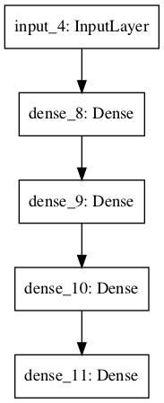

```python
# plot graph
plot_model(model, to_file='multilayer_perceptron_graph.png')
```

### 1.3.2 Convolutional Neural Network

In this section, we will define a convolutional neural network for image classification. The model receives black and white 64 × 64 images as input, then has a sequence of two convolutional and pooling layers as feature extractors, followed by a fully connected layer to interpret the features and an output layer with a sigmoid activation for two-class predictions.

```python
# example of a convolutional neural network
from tensorflow.keras.layers import Flatten
from tensorflow.keras.layers import Conv2D
from tensorflow.keras.layers import MaxPooling2D

visible = Input(shape=(64,64,1))
conv1 = Conv2D(32, (4,4), activation='relu')(visible)
pool1 = MaxPooling2D()(conv1)
conv2 = Conv2D(16, (4,4), activation='relu')(pool1)
pool2 = MaxPooling2D()(conv2)
flat1 = Flatten()(pool2)
hidden1 = Dense(10, activation='relu')(flat1)
output = Dense(1, activation='sigmoid')(hidden1)
model = Model(inputs=visible, outputs=output)
# summarize layers
model.summary()
```

```
Model: "model_2"
_________________________________________________________________
Layer (type)                 Output Shape              Param #
=================================================================
input_5 (InputLayer)         [(None, 64, 64, 1)]       0
_________________________________________________________________
conv2d (Conv2D)              (None, 61, 61, 32)        544
_________________________________________________________________
max_pooling2d (MaxPooling2D) (None, 30, 30, 32)        0
_________________________________________________________________
conv2d_1 (Conv2D)            (None, 27, 27, 16)        8208
_________________________________________________________________
max_pooling2d_1 (MaxPooling2 (None, 13, 13, 16)        0
_________________________________________________________________
flatten (Flatten)            (None, 2704)              0
_________________________________________________________________
dense_12 (Dense)             (None, 10)                27050
_________________________________________________________________
dense_13 (Dense)             (None, 1)                 11
=================================================================
Total params: 35,813
Trainable params: 35,813
Non-trainable params: 0
_________________________________________________________________
```

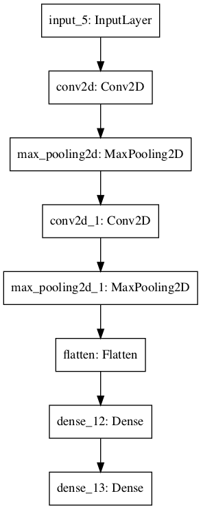

```python
# plot graph
plot_model(model, to_file='convolutional_neural_network.png')
```

### 1.3.3 Recurrent Neural Network

In this section, we will define a long short-term memory recurrent neural network for sequence classification.

The model expects 100 time steps of one feature as input. The model has a single LSTM hidden layer to extract features from the sequence, followed by a fully connected layer to interpret the LSTM output, followed by an output layer for making binary predictions.

```python
# example of a recurrent neural network
from tensorflow.keras.layers import LSTM

visible = Input(shape=(100,1))
hidden1 = LSTM(10)(visible)
hidden2 = Dense(10, activation='relu')(hidden1)
output = Dense(1, activation='sigmoid')(hidden2)
model = Model(inputs=visible, outputs=output)

# summarize layers
model.summary()
```

```
Model: "model_3"
_________________________________________________________________
Layer (type)                 Output Shape              Param #
=================================================================
input_6 (InputLayer)         [(None, 100, 1)]          0
_________________________________________________________________
lstm (LSTM)                  (None, 10)                480
_________________________________________________________________
dense_14 (Dense)             (None, 10)                110
_________________________________________________________________
dense_15 (Dense)             (None, 1)                 11
=================================================================
Total params: 601
Trainable params: 601
Non-trainable params: 0
_________________________________________________________________
```

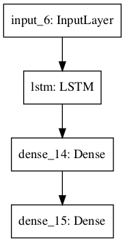

```python
# plot graph
plot_model(model, to_file='recurrent_neural_network.png')
```